# A1D37

Yue Han 1005299614

```r
library(tidyverse)
library(MASS)
```

## 2.)

Defining matrices $A, B, C$

```r
A = matrix(c(20, 9, 15, 16, 16, 5, 5, 6, 14),3,3)
A
```

```
##      [,1] [,2] [,3]
## [1,]   20   16    5
## [2,]    9   16    6
## [3,]   15    5   14
```

```r
B = matrix(c(7, 15, 8, 19, 20, 15, 15, 13, 14),3,3)
B
```

```
##      [,1] [,2] [,3]
## [1,]    7   19   15
## [2,]   15   20   13
## [3,]    8   15   14
```

```r
C = matrix(c(1, 6, 20, 11, 12, 20, 16, 9, 15),3,3)
C
```

```
##      [,1] [,2] [,3]
## [1,]    1   11   16
## [2,]    6   12    9
## [3,]   20   20   15
```

Matrix Multiplication results: $ABC, BCA, CAB, $and $ACB$ respectively

```r
A%*%B%*%C
```

```
##       [,1]  [,2]  [,3]
## [1,] 16630 25480 22365
## [2,] 12377 19373 17250
## [3,] 13582 20072 17317
```

```r
B%*%C%*%A
```

```
##       [,1]  [,2]  [,3]
## [1,] 21485 18956 12847
## [2,] 23110 20035 14575
## [3,] 19587 17181 11800
```

```r
C%*%A%*%B
```

```
##       [,1]  [,2]  [,3]
## [1,]  8953 16686 13051
## [2,]  9360 16977 12966
## [3,] 19800 36045 27390
```

```r
A%*%C%*%B
```

```
##       [,1]  [,2]  [,3]
## [1,] 13504 22429 17442
## [2,] 10764 18165 14010
## [3,] 13810 23700 18370
```

$tr(ABC), tr(BCA), tr(CAB), tr(ACB)$ results respectively

```r
sum(diag(A%*%B%*%C))
```

```
## [1] 53320
```

```r
sum(diag(B%*%C%*%A))
```

```
## [1] 53320
```

```r
sum(diag(C%*%A%*%B))
```

```
## [1] 53320
```

```r
sum(diag(A%*%C%*%B))
```

```
## [1] 50039
```

$tr(ABC), tr(BCA), tr(CAB)$ have the same trace

## 3

a.)

```r
X = data.matrix(read.table("p1_4.txt", header=F, sep = "\t", row.names = 1))

X = matrix(c(108.28,   17.05,   1484.10,
  152.36,   16.59,    750.33,
   95.04,   10.91 ,   766.42,
   65.45 ,  14.14 ,  1110.46,
   62.97 ,   9.52,   1031.29,
  263.99 ,  25.33 ,   195.26,
  265.19 ,  18.54,    193.83,
  285.06 ,  15.73,    191.11,
   92.01 ,   8.10 ,  1175.16,
  165.68 ,  11.13,    211.15), 10, 3, byrow = T)
X
```

```
##         [,1]  [,2]    [,3]
##  [1,] 108.28 17.05 1484.10
##  [2,] 152.36 16.59  750.33
##  [3,]  95.04 10.91  766.42
##  [4,]  65.45 14.14 1110.46
##  [5,]  62.97  9.52 1031.29
##  [6,] 263.99 25.33  195.26
##  [7,] 265.19 18.54  193.83
##  [8,] 285.06 15.73  191.11
##  [9,]  92.01  8.10 1175.16
## [10,] 165.68 11.13  211.15
```

sample mean vector $\overline{x}$

```r
Xbar = apply(X,2,mean)
Xbar
```

```
## [1] 155.603  14.704 710.911
```

Covariance Matrix $S_n$

```r
mean = mean(X)
n = dim(X) [1]
p = dim(X) [2]
one = as.matrix(c(rep(1,n)))
I = diag(n)
I
```

```
##       [,1] [,2] [,3] [,4] [,5] [,6] [,7] [,8] [,9] [,10]
##  [1,]    1    0    0    0    0    0    0    0    0     0
##  [2,]    0    1    0    0    0    0    0    0    0     0
##  [3,]    0    0    1    0    0    0    0    0    0     0
##  [4,]    0    0    0    1    0    0    0    0    0     0
##  [5,]    0    0    0    0    1    0    0    0    0     0
##  [6,]    0    0    0    0    0    1    0    0    0     0
##  [7,]    0    0    0    0    0    0    1    0    0     0
##  [8,]    0    0    0    0    0    0    0    1    0     0
##  [9,]    0    0    0    0    0    0    0    0    1     0
## [10,]    0    0    0    0    0    0    0    0    0     1
```

```r
J = one%*%t(one)
J
```

```
##       [,1] [,2] [,3] [,4] [,5] [,6] [,7] [,8] [,9] [,10]
##  [1,]    1    1    1    1    1    1    1    1    1     1
##  [2,]    1    1    1    1    1    1    1    1    1     1
##  [3,]    1    1    1    1    1    1    1    1    1     1
##  [4,]    1    1    1    1    1    1    1    1    1     1
##  [5,]    1    1    1    1    1    1    1    1    1     1
##  [6,]    1    1    1    1    1    1    1    1    1     1
##  [7,]    1    1    1    1    1    1    1    1    1     1
##  [8,]    1    1    1    1    1    1    1    1    1     1
##  [9,]    1    1    1    1    1    1    1    1    1     1
## [10,]    1    1    1    1    1    1    1    1    1     1
```

```r
C = I-(1/n)*J #centering matrix
C
```

```
##       [,1] [,2] [,3] [,4] [,5] [,6] [,7] [,8] [,9] [,10]
##  [1,]  0.9 -0.1 -0.1 -0.1 -0.1 -0.1 -0.1 -0.1 -0.1  -0.1
##  [2,] -0.1  0.9 -0.1 -0.1 -0.1 -0.1 -0.1 -0.1 -0.1  -0.1
##  [3,] -0.1 -0.1  0.9 -0.1 -0.1 -0.1 -0.1 -0.1 -0.1  -0.1
##  [4,] -0.1 -0.1 -0.1  0.9 -0.1 -0.1 -0.1 -0.1 -0.1  -0.1
##  [5,] -0.1 -0.1 -0.1 -0.1  0.9 -0.1 -0.1 -0.1 -0.1  -0.1
##  [6,] -0.1 -0.1 -0.1 -0.1 -0.1  0.9 -0.1 -0.1 -0.1  -0.1
##  [7,] -0.1 -0.1 -0.1 -0.1 -0.1 -0.1  0.9 -0.1 -0.1  -0.1
##  [8,] -0.1 -0.1 -0.1 -0.1 -0.1 -0.1 -0.1  0.9 -0.1  -0.1
##  [9,] -0.1 -0.1 -0.1 -0.1 -0.1 -0.1 -0.1 -0.1  0.9  -0.1
## [10,] -0.1 -0.1 -0.1 -0.1 -0.1 -0.1 -0.1 -0.1 -0.1   0.9
```

```r
Xc = C%*%X
Xc
```

```
##          [,1]   [,2]     [,3]
##  [1,] -47.323  2.346  773.189
##  [2,]  -3.243  1.886   39.419
##  [3,] -60.563 -3.794   55.509
##  [4,] -90.153 -0.564  399.549
##  [5,] -92.633 -5.184  320.379
##  [6,] 108.387 10.626 -515.651
##  [7,] 109.587  3.836 -517.081
##  [8,] 129.457  1.026 -519.801
##  [9,] -63.593 -6.604  464.249
## [10,]  10.077 -3.574 -499.761
```

```r
Sn = (1/n)*t(Xc)%*%Xc
Sn #covariance matrix
```

```
##             [,1]       [,2]        [,3]
## [1,]   6728.8079  273.25676 -32018.3636
## [2,]    273.2568   23.57128   -948.4447
## [3,] -32018.3636 -948.44465 213348.8428
```

or just

```r
((n-1)/n)*cov(X)
```

```
##             [,1]       [,2]        [,3]
## [1,]   6728.8079  273.25676 -32018.3636
## [2,]    273.2568   23.57128   -948.4447
## [3,] -32018.3636 -948.44465 213348.8428
```

b.)

```r
data <- read.table("p1_4.txt", header = F)
data
```

| V1 | V2 | V3 |
| --- | --- | --- |
| 108.28 | 17.05 | 1484.10 |
| 152.36 | 16.59 | 750.33 |
| 95.04 | 10.91 | 766.42 |
| 65.45 | 14.14 | 1110.46 |
| 62.97 | 9.52 | 1031.29 |
| 263.99 | 25.33 | 195.26 |
| 265.19 | 18.54 | 193.83 |
| 285.06 | 15.73 | 191.11 |
| 92.01 | 8.10 | 1175.16 |
| 165.68 | 11.13 | 211.15 |

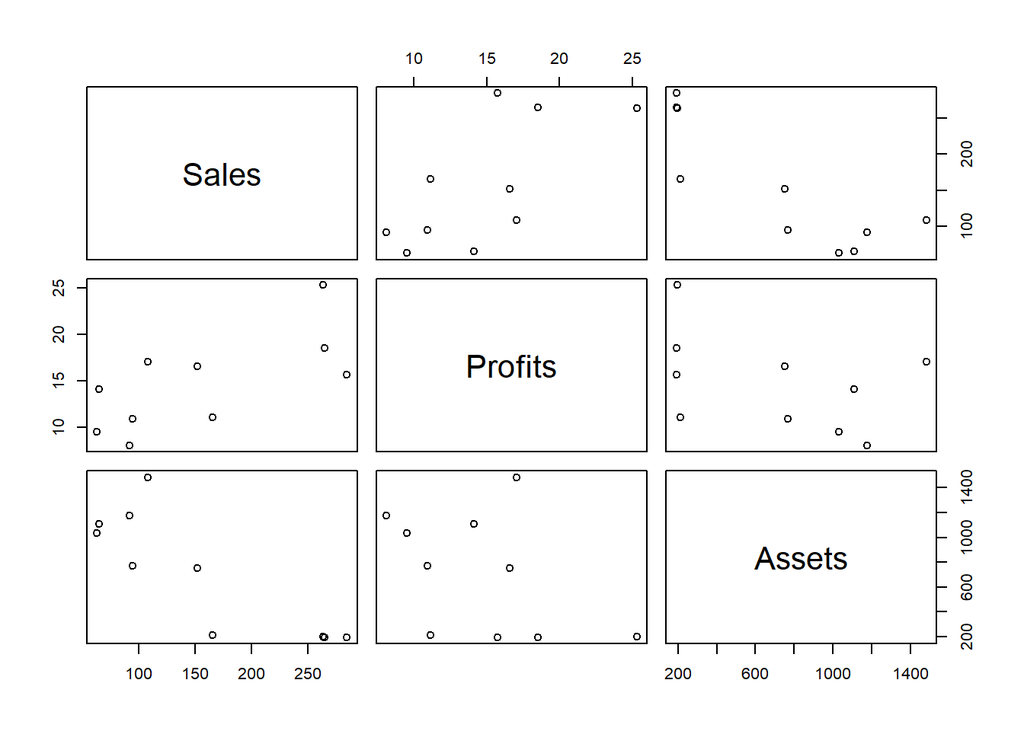

```r
cols = c("Sales","Profits","Assets")
colnames(data) = cols

plot(data)
```

We see from the plot that there is a positive correlation between profits and sales while there is a negative correlation between profits and assets and between sales and assets. This is verified by the following correlation matrix R which has corresponding positive and negative correlations as suggested above

correlation matrix R

```r
sii <- sqrt(diag(Sn))
D <- diag(sii) #diagonal of sii
D
```

```
##          [,1]     [,2]    [,3]
## [1,] 82.02931 0.000000   0.000
## [2,]  0.00000 4.855027   0.000
## [3,]  0.00000 0.000000 461.897
```

```r
Dinv <- solve(D) #inverse of D
Xs <- C%*%X%*%Dinv
R <- (1/n)*t(Xs)%*%Xs
R
```

```
##            [,1]       [,2]       [,3]
## [1,]  1.0000000  0.6861360 -0.8450549
## [2,]  0.6861360  1.0000000 -0.4229366
## [3,] -0.8450549 -0.4229366  1.0000000
```

c.)

```r
C = I-(1/n)*J #centering matrix
C
```

```
##       [,1] [,2] [,3] [,4] [,5] [,6] [,7] [,8] [,9] [,10]
##  [1,]  0.9 -0.1 -0.1 -0.1 -0.1 -0.1 -0.1 -0.1 -0.1  -0.1
##  [2,] -0.1  0.9 -0.1 -0.1 -0.1 -0.1 -0.1 -0.1 -0.1  -0.1
##  [3,] -0.1 -0.1  0.9 -0.1 -0.1 -0.1 -0.1 -0.1 -0.1  -0.1
##  [4,] -0.1 -0.1 -0.1  0.9 -0.1 -0.1 -0.1 -0.1 -0.1  -0.1
##  [5,] -0.1 -0.1 -0.1 -0.1  0.9 -0.1 -0.1 -0.1 -0.1  -0.1
##  [6,] -0.1 -0.1 -0.1 -0.1 -0.1  0.9 -0.1 -0.1 -0.1  -0.1
##  [7,] -0.1 -0.1 -0.1 -0.1 -0.1 -0.1  0.9 -0.1 -0.1  -0.1
##  [8,] -0.1 -0.1 -0.1 -0.1 -0.1 -0.1 -0.1  0.9 -0.1  -0.1
##  [9,] -0.1 -0.1 -0.1 -0.1 -0.1 -0.1 -0.1 -0.1  0.9  -0.1
## [10,] -0.1 -0.1 -0.1 -0.1 -0.1 -0.1 -0.1 -0.1 -0.1   0.9
```

```r
Xc = C%*%X
Xc
```

```
##          [,1]   [,2]     [,3]
##  [1,] -47.323  2.346  773.189
##  [2,]  -3.243  1.886   39.419
##  [3,] -60.563 -3.794   55.509
##  [4,] -90.153 -0.564  399.549
##  [5,] -92.633 -5.184  320.379
##  [6,] 108.387 10.626 -515.651
##  [7,] 109.587  3.836 -517.081
##  [8,] 129.457  1.026 -519.801
##  [9,] -63.593 -6.604  464.249
## [10,]  10.077 -3.574 -499.761
```

## 6

Spectral Decomposition $A = P\Lambda P'$ $\Lambda = diag(\lambda_1 , ..., \lambda_k)$ $P = (e_1,...,e_k)$

```r
A = matrix(c(404.6, 282.4, 118.3, 109.4, 282.4, 284.4, -13.6, 45.4, 118.3, -13.6, 599.7, 488.3, 109.4, 45.4, 488.3, 447.4), 4, 4, byrow = T)
A
```

```
##       [,1]  [,2]  [,3]  [,4]
## [1,] 404.6 282.4 118.3 109.4
## [2,] 282.4 284.4 -13.6  45.4
## [3,] 118.3 -13.6 599.7 488.3
## [4,] 109.4  45.4 488.3 447.4
```

```r
ev = eigen(A)
P = ev$vectors
P
```

```
##            [,1]       [,2]       [,3]       [,4]
## [1,] -0.2841936  0.7077960 -0.5510890  0.3384668
## [2,] -0.1260140  0.6385478  0.5972527 -0.4686859
## [3,] -0.7174597 -0.2624042 -0.3134530 -0.5640415
## [4,] -0.6233827 -0.1497517  0.4912610  0.5896024
```

```r
Lambda = diag(ev$values)
Lambda
```

```
##          [,1]     [,2]     [,3]     [,4]
## [1,] 1068.443   0.0000  0.00000 0.000000
## [2,]    0.000 592.3669  0.00000 0.000000
## [3,]    0.000   0.0000 68.30835 0.000000
## [4,]    0.000   0.0000  0.00000 6.981935
```

```r
P%*%Lambda%*%t(P)
```

```
##       [,1]  [,2]  [,3]  [,4]
## [1,] 404.6 282.4 118.3 109.4
## [2,] 282.4 284.4 -13.6  45.4
## [3,] 118.3 -13.6 599.7 488.3
## [4,] 109.4  45.4 488.3 447.4
```

$A^{1/2} = P\Lambda ^{1/2} P'$ where $\Lambda ^{1/2} = diag( \sqrt{ \lambda_1 }, ...,\sqrt{ \lambda_k })$

```r
sqrtLambda = diag(sqrt(ev$values))
sqrtLambda
```

```
##          [,1]     [,2]     [,3]     [,4]
## [1,] 32.68704  0.00000 0.000000 0.000000
## [2,]  0.00000 24.33859 0.000000 0.000000
## [3,]  0.00000  0.00000 8.264886 0.000000
## [4,]  0.00000  0.00000 0.000000 2.642335
```

```r
P%*%sqrtLambda%*%t(P)
```

```
##           [,1]      [,2]      [,3]      [,4]
## [1,] 17.645774  9.031242  3.067667  1.500912
## [2,]  9.031242 13.971557 -1.971632  1.935183
## [3,]  3.067667 -1.971632 20.154149 13.424319
## [4,]  1.500912  1.935183 13.424319 16.161373
```

## 7

b.) i.)

```r
A. = matrix(c(-6, 2, -2, -3, 3, -1, 5, 2, -3, 1, 3, -1),3,4, byrow = T)
A.
```

```
##      [,1] [,2] [,3] [,4]
## [1,]   -6    2   -2   -3
## [2,]    3   -1    5    2
## [3,]   -3    1    3   -1
```

```r
A_ = ginv(A.)
```

ii.) $AA^-A$ is

```r
A.%*%A_%*%A.
```

```
##      [,1] [,2] [,3] [,4]
## [1,]   -6    2   -2   -3
## [2,]    3   -1    5    2
## [3,]   -3    1    3   -1
```

## 8

Using result 4.6 p160 of textbook or lecture 3 pg 15 since $\sum_{22} > 0$

$$\mu_{1|2} = \begin{pmatrix}
-0.02121836 & -0.01660601 & -0.3576434\\
-0.17843305 & 0.32452988 & -0.6153722
\end{pmatrix} x_2$$

$$\sum_{1|2} = \begin{pmatrix}
3.8746860 & -0.4681063 \\
-0.4681063 & 2.6303564
\end{pmatrix}$$

```r
S = matrix(c(4.2, -0.01, -0.08, -0.32, -0.89,
-0.01, 3.56, -0.25, 0.3, -1.28,
-0.08, -0.25, 2.16, 0.55, 0.07,
-0.32, 0.3, 0.55, 2.63, 0.74,
-0.89, -1.28, 0.07, 0.74, 2.45), 5,5, byrow = T)
S
```

```
##       [,1]  [,2]  [,3]  [,4]  [,5]
## [1,]  4.20 -0.01 -0.08 -0.32 -0.89
## [2,] -0.01  3.56 -0.25  0.30 -1.28
## [3,] -0.08 -0.25  2.16  0.55  0.07
## [4,] -0.32  0.30  0.55  2.63  0.74
## [5,] -0.89 -1.28  0.07  0.74  2.45
```

```r
mu = c(0,0,0,0,0)

S_twotwo = matrix(c(2.16, 0.55, 0.07, 0.55, 2.63, 0.74, 0.07, 0.74, 2.45), 3, 3, byrow = T)
S_twotwo
```

```
##      [,1] [,2] [,3]
## [1,] 2.16 0.55 0.07
## [2,] 0.55 2.63 0.74
## [3,] 0.07 0.74 2.45
```

```r
det(S_twotwo) #>0
```

```
## [1] 12.03811
```

```r
S_oneone =  matrix(c(4.2, -0.01,-0.01, 3.56), 2, 2, byrow = T)
S_oneone
```

```
##       [,1]  [,2]
## [1,]  4.20 -0.01
## [2,] -0.01  3.56
```

```r
S_onetwo = matrix(c(-0.08, -0.32, -0.89, -0.25, 0.3, -1.28),2, 3, byrow = T)
S_onetwo
```

```
##       [,1]  [,2]  [,3]
## [1,] -0.08 -0.32 -0.89
## [2,] -0.25  0.30 -1.28
```

```r
S_twoone = matrix(c(-0.08, -0.25, -0.32, 0.3,  -0.89, -1.28), 3, 2, byrow = T)
S_twoone
```

```
##       [,1]  [,2]
## [1,] -0.08 -0.25
## [2,] -0.32  0.30
## [3,] -0.89 -1.28
```

```r
detS_twotwo = solve(S_twotwo)
detS_twotwo
```

```
##             [,1]       [,2]        [,3]
## [1,]  0.48976949 -0.1076332  0.01851619
## [2,] -0.10763316  0.4391968 -0.12958012
## [3,]  0.01851619 -0.1295801  0.44677272
```

```r
mug_onetwo = S_onetwo %*% detS_twotwo #mu = c(0,0,0,0,0)
mug_onetwo
```

```
##             [,1]        [,2]       [,3]
## [1,] -0.02121836 -0.01660601 -0.3576434
## [2,] -0.17843305  0.32452988 -0.6153722
```

```r
Sg_onetwo = S_oneone - S_onetwo %*% detS_twotwo %*% S_twoone
Sg_onetwo
```

```
##            [,1]       [,2]
## [1,]  3.8746860 -0.4681063
## [2,] -0.4681063  2.6303564
```

b.)

```r
det(S_twotwo)
```

```
## [1] 12.03811
```

```r
det(Sg_onetwo)
```

```
## [1] 9.972682
```

```r
det(S_twotwo) * det(Sg_onetwo)
```

```
## [1] 120.0523
```

```r
det(S)
```

```
## [1] 120.0523
```

## 10

```r
x = read.table("data_chisqplot.txt", header = TRUE)

head(x)
```

|  | x1 | x2 |
| --- | --- | --- |
| 1 | 47.52 | 67.47 |
| 2 | 50.76 | 62.49 |
| 3 | 46.62 | 57.88 |
| 4 | 47.38 | 62.20 |
| 5 | 45.74 | 59.11 |
| 6 | 46.23 | 59.01 |

19 were less than $\chi_p^2(0.5)$, so 76% of them were less. We expect around 50%. 76% is a lot larger than 50% so likely not univariate normality for each variable

```r
S = cov(x)
n = nrow(x)
p = ncol(x)
xbar = colMeans(x)
dsq = apply(x, MARGIN = 1, function(x) t(x - xbar)%*%solve(S)%*%(x - xbar))
dsq
```

```
##  [1]  7.38083045  0.74983035  0.59872191  0.77284313  0.35881941  0.28609181
##  [7]  0.49599731  0.52330734 18.82971297  1.80897455  0.56863484  0.03479158
## [13]  2.00162039  1.04114638  0.69331747  0.77917700  0.57515734  0.69594878
## [19]  0.69769845  3.99584884  0.73682060  2.42647391  0.63767460  0.67680614
## [25]  0.63375447
```

```r
n*mean(dsq < qchisq(0.5, p))
```

```
## [1] 19
```

```r
mean(dsq < qchisq(0.5, p))
```

```
## [1] 0.76
```

so 18.82971297 seems to be an outlier

```r
qchisq(1-0.005, p)
```

```
## [1] 10.59663
```

b.) Not roughly a straight line. There is one extremely large $d_i^2$ And as we have seen above there is one major outlier 18.82971297 > $\chi_p^2(1-0.005) = 10.59663$

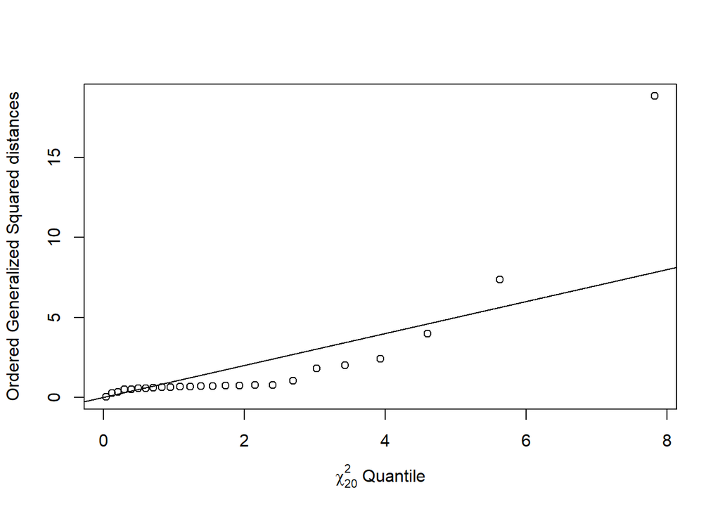

```r
plot(qchisq((1:n - 1/2)/n, df = p), sort(dsq), xlab = expression(paste(chi[20]^2, " Quantile")), ylab = "Ordered Generalized Squared distances")
abline(a = 0, b = 1)
```